# Chap12 Section 1

Mijeong Kim

```r
library(tsibble)
library(tsibbledata)
library(tibble)
library(dplyr)
library(knitr)
library(ggplot2)
library(fpp3)
library(fpp2)
library(seasonal)
library(feasts)
```

# 12. 고급 예측 기법

## 12.1 복잡한 계절성

#### 고빈도 시계열의 복잡한 계절성

지금까지는 주로 **월별** 또는 **분기별**과 같은 단순한 계절 패턴을 가진 시계열을 고려하였다. 그러나 데이터의 빈도가 높아질수록 계절 패턴은 더욱 복잡해진다.

예를 들어:

- **일 단위 데이터**는 주간 패턴과 연간 패턴을 동시에 가질 수 있다.
- **시간 단위 또는 분 단위 데이터**는 일별, 주별, 연별 계절성이 동시에 존재할 수 있다.
- **주 단위 데이터**는 1년이 정확히 52주가 아니기 때문에, 연간 주기는 평균적으로 약 $365.25 / 7 \approx 52.179$가 되어 예측이 어려워질 수 있다.

대부분의 기존 시계열 모델은 이러한 복잡한 다중 계절성을 충분히 처리하지 못한다.

#### 필요한 계절성만 포함하기

모든 가능한 계절 주기를 모델에 포함할 필요는 없다. 예를 들어:

- **180일 분량의 데이터**만 있다면, **연간 계절성**은 무시할 수 있다.
- **자연 현상(예: 기온)**을 측정한 데이터는 주간 계절성을 무시해도 된다.

#### Figure 12.1: 은행 콜센터 예제

Figure 12.1은 **북미 상업은행**의 **5분 단위 콜 수** 데이터를 보여준다. 데이터는 **33주 동안의 평일(월~금)** 오전 7시부터 오후 9시 5분까지 수집되었다.

- 하루에는 5분 간격으로 **169개 시점(period)**이 존재한다.
- 주간 패턴은 $169 \times 5 = 845$로, 약한 주기성을 가진다. (예: **월요일**의 통화량이 다른 요일보다 높음)
- 더 긴 기간의 데이터가 존재한다면, **연간 계절성**도 관찰될 수 있다.

이 예제는 고빈도 시계열에서 **다중 계절성(multiseasonality)**을 다루는 필요성을 잘 보여준다.

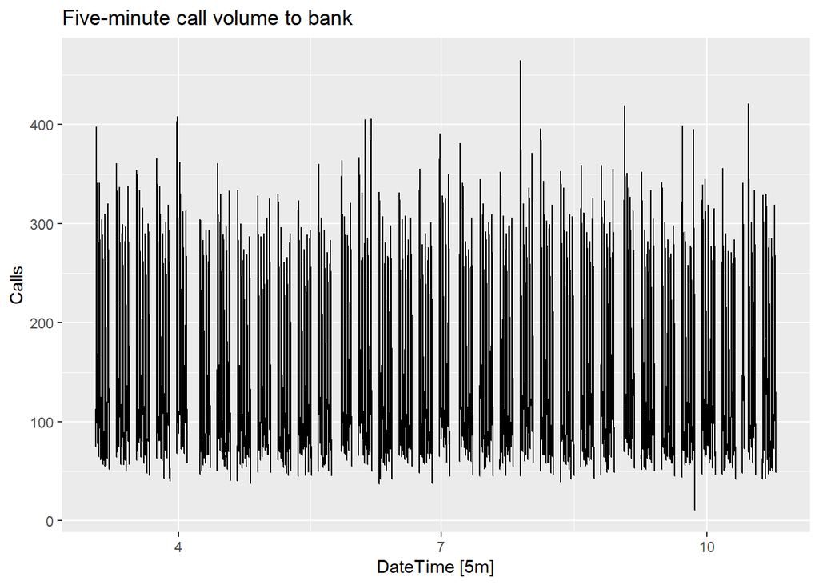

```r
bank_calls |>
  fill_gaps() |>
  autoplot(Calls) +
  labs(y = "Calls",
       title = "Five-minute call volume to bank")
```

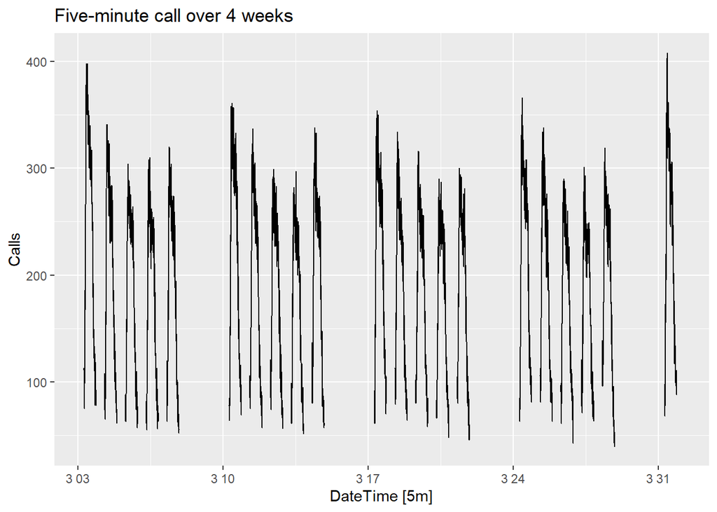

```r
bank_March03<-bank_calls|>
  fill_gaps() |>
  filter(year(DateTime)==2003, month(DateTime)==3)
bank_March03|>autoplot(Calls)+
  labs(y = "Calls",
  title = "Five-minute call over 4 weeks")
```

Figure 12.1: Five-minute call volume handled on weekdays between 7:00am and 9:05pm in a large North American commercial bank. Top panel: data from 3 March – 24 October 2003. Bottom panel: first four weeks of data.

이 시계열은 여러 계절 주기뿐만 아니라, 업무 시간 사이에 결측값이 존재하는 추가적인 복잡성도 가지고 있다.

### 다중 계절성 주기를 고려하는 STL

STL() 함수는 복수의 계절성을 처리할 수 있으며, 여러 계절 성분, 추세, 잔차를 반환한다. 이 경우 결측값을 피하기 위해 tsibble을 재인덱싱하고, 계절 주기를 명시적으로 지정해야 한다.

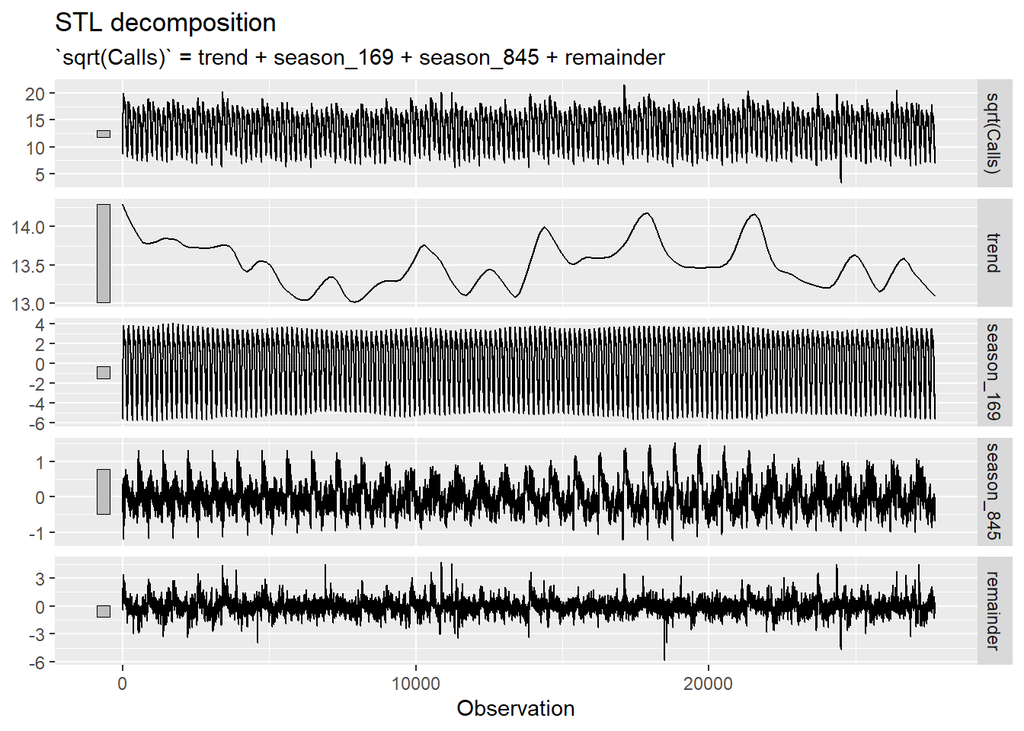

```r
calls <- bank_calls |>
  mutate(t = row_number()) |>
  update_tsibble(index = t, regular = TRUE)
calls |>
  model(
    STL(sqrt(Calls) ~ season(period = 169) +
                      season(period = 5*169),
        robust = TRUE)
  ) |>
  components() |>
  autoplot() + labs(x = "Observation")
```

Figure 12.2: STL decomposition with multiple seasonality for the call volume data.

그래프에는 하루 시간대별(3번째 패널)과 요일별(4번째 패널) 두 가지 계절 패턴이 나타난다. 추세와 주간 계절성은 스케일이 좁아 변화가 적음을 의미한다.

이 분해 결과는 예측에도 활용되며,

- 계절 성분은 계절 naive 방식,
- 계절 조정 데이터는 ETS로 예측한다.

재인덱싱 과정에서 사라진 시간 정보를 복원해야 하므로 코드가 다소 복잡하며, STL의 제곱근 변환은 예측값이 음수가 되지 않도록 보장한다.

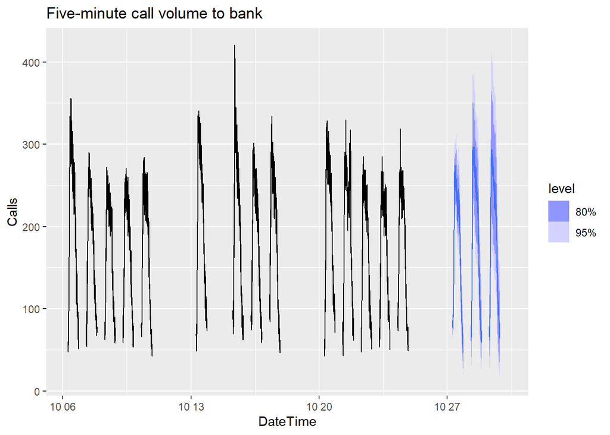

```r
# Forecasts from STL+ETS decomposition
my_dcmp_spec <- decomposition_model(
  STL(sqrt(Calls) ~ season(period = 169) +
                    season(period = 5*169),
      robust = TRUE),
  ETS(season_adjust ~ season("N"))
)
fc <- calls |>
  model(my_dcmp_spec) |>
  forecast(h = 5 * 169)

# Add correct time stamps to fable
fc_with_times <- bank_calls |>
  new_data(n = 7 * 24 * 60 / 5) |>
  mutate(time = format(DateTime, format = "%H:%M:%S")) |>
  filter(
    time %in% format(bank_calls$DateTime, format = "%H:%M:%S"),
    wday(DateTime, week_start = 1) <= 5
  ) |>
  mutate(t = row_number() + max(calls$t)) |>
  left_join(fc, by = "t") |>
  as_fable(response = "Calls", distribution = Calls)

# Plot results with last 3 weeks of data
fc_with_times |>
  fill_gaps() |>
  autoplot(bank_calls |> tail(14 * 169) |> fill_gaps()) +
  labs(y = "Calls",
       title = "Five-minute call volume to bank")
```

Figure 12.3: Forecasts of the call volume data using an STL decomposition with the seasonal components forecast using a seasonal naïve method, and the seasonally adjusted data forecast using ETS.

### 다중 계절성 주기를 고려하는 동적 조화 회귀

다중 계절성을 가진 시계열 자료는 **Fourier 항**과 **ARIMA 오차를 갖는 동적 회귀 모형**을 통해 분석할 수 있다.

#### 계절 주기

- 하루 단위 계절성: 주기 169
- 주간 계절성: 주기 845

Fourier 항은 다음과 같은 형태를 가진다:

$$\sin\left(\frac{2\pi kt}{m}\right), \quad \cos\left(\frac{2\pi
kt}{m}\right)$$
여기서 $m = 169, 845$, $k = 1, 2, \dots$이다.

`fourier()` 함수로 위 항들을 자동 생성할 수 있다.

#### 모형 설정

- 하루 계절성에 대해 Fourier 항 10개 사용
- 주간 계절성에 대해 Fourier 항 5개 사용
- 예측값이 음수가 되지 않도록 **제곱근 변환**을 적용한다
- ARIMA 오차는 다음과 같이 설정한다:
  - $D = d = 0$: 비정상성은 회귀항으로 처리
  - $P = Q = 0$: 계절성도 Fourier 회귀항으로 처리

#### 구현 시 유의사항

AICc를 이용해 Fourier 항 개수를 선택할 수도 있으나, 계절 주기가 큰 경우 과대추정하는 경향이 있다.  
따라서 주관적 판단을 바탕으로 항의 개수를 정하는 것이 더 안정적이다.

```r
fit <- calls |>
  model(
    dhr = ARIMA(sqrt(Calls) ~ PDQ(0, 0, 0) + pdq(d = 0) +
                  fourier(period = 169, K = 10) +
                  fourier(period = 5*169, K = 5)))
report(fit)
```

```
## Series: Calls
## Model: LM w/ ARIMA(1,0,3) errors
## Transformation: sqrt(Calls)
##
## Coefficients:
##          ar1      ma1      ma2      ma3  fourier(period = 169, K = 10)C1_169
##       0.9871  -0.7253  -0.0415  -0.0321                              -3.1438
## s.e.  0.0011   0.0061   0.0075   0.0060                               0.0252
##       fourier(period = 169, K = 10)S1_169  fourier(period = 169, K = 10)C2_169
##                                    1.9775                              -1.3323
## s.e.                               0.0253                               0.0138
##       fourier(period = 169, K = 10)S2_169  fourier(period = 169, K = 10)C3_169
##                                    0.6322                              -0.4468
## s.e.                               0.0139                               0.0100
##       fourier(period = 169, K = 10)S3_169  fourier(period = 169, K = 10)C4_169
##                                   -0.3943                              -0.1932
## s.e.                               0.0100                               0.0082
##       fourier(period = 169, K = 10)S4_169  fourier(period = 169, K = 10)C5_169
##                                   -0.3411                               0.0400
## s.e.                               0.0082                               0.0072
##       fourier(period = 169, K = 10)S5_169  fourier(period = 169, K = 10)C6_169
##                                   -0.1127                               0.0983
## s.e.                               0.0072                               0.0066
##       fourier(period = 169, K = 10)S6_169  fourier(period = 169, K = 10)C7_169
##                                   -0.0299                               0.0156
## s.e.                               0.0066                               0.0062
##       fourier(period = 169, K = 10)S7_169  fourier(period = 169, K = 10)C8_169
##                                   -0.0002                              -0.0347
## s.e.                               0.0062                               0.0059
##       fourier(period = 169, K = 10)S8_169  fourier(period = 169, K = 10)C9_169
##                                    0.0161                               0.0030
## s.e.                               0.0059                               0.0057
##       fourier(period = 169, K = 10)S9_169  fourier(period = 169, K = 10)C10_169
##                                   -0.0319                                0.0409
## s.e.                               0.0057                                0.0056
##       fourier(period = 169, K = 10)S10_169
##                                    -0.0375
## s.e.                                0.0056
##       fourier(period = 5 * 169, K = 5)C1_845
##                                      -0.0248
```

[output cut: 10 more lines]

```
##       fourier(period = 5 * 169, K = 5)C3_845
##                                      -0.0068
## s.e.                                  0.0381
##       fourier(period = 5 * 169, K = 5)S3_845
##                                       0.0491
## s.e.                                  0.0381
##       fourier(period = 5 * 169, K = 5)C4_845
##                                       0.0150
## s.e.                                  0.0305
##       fourier(period = 5 * 169, K = 5)S4_845  intercept
##                                       0.0611    13.5275
## s.e.                                  0.0305     0.0532
##
## sigma^2 estimated as 0.3232:  log likelihood=-23659.23
## AIC=47386.45   AICc=47386.54   BIC=47666.26
```

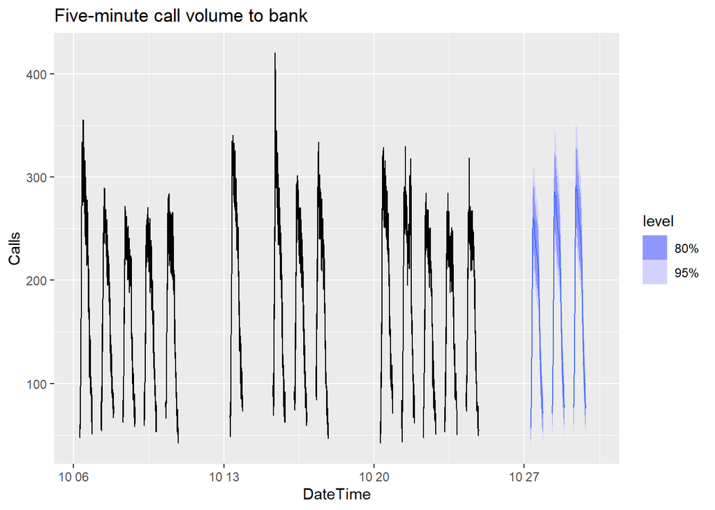

```r
fc <- fit |> forecast(h = 5 * 169)

# Add correct time stamps to fable
fc_with_times <- bank_calls |>
  new_data(n = 7 * 24 * 60 / 5) |>
  mutate(time = format(DateTime, format = "%H:%M:%S")) |>
  filter(
    time %in% format(bank_calls$DateTime, format = "%H:%M:%S"),
    wday(DateTime, week_start = 1) <= 5
  ) |>
  mutate(t = row_number() + max(calls$t)) |>
  left_join(fc, by = "t") |>
  as_fable(response = "Calls", distribution = Calls)

# Plot results with last 3 weeks of data
fc_with_times |>
  fill_gaps() |>
  autoplot(bank_calls |> tail(14 * 169) |> fill_gaps()) +
  labs(y = "Calls",
       title = "Five-minute call volume to bank")
```

Figure 12.4: Forecasts from a dynamic harmonic regression applied to the call volume data.

이 모형은 총 **33개의 모수**를 포함하는 대규모 모형이다:

- ARMA 계수 4개
- 주기 169에 대한 Fourier 계수 20개
- 주기 845에 대한 Fourier 계수 8개

주기 845에 대한 모든 Fourier 항이 사용되지 않은 이유는,  
**845 = 5 × 169** 이므로 두 주기 간에 **중복되는 성분이 존재**하기 때문이다.  
따라서 일부 항은 제거하여 **모형의 중복성과 과적합을 줄였다**.

### 예시: 전력 수요 모형

이와 같은 모형의 대표적인 활용 예는 **전력 수요 분석**이다.

그림 12.5는 **호주 빅토리아 주의 반시간 단위 전력 수요(MWh)**를 나타내며,  
2012년부터 2014년까지의 데이터를 포함한다.

함께 제시된 **기온 자료**는 빅토리아 주 최대 도시인 **멜버른의 섭씨 온도**로,  
전력 수요와의 관계를 살펴보기 위한 보조 변수로 활용된다.

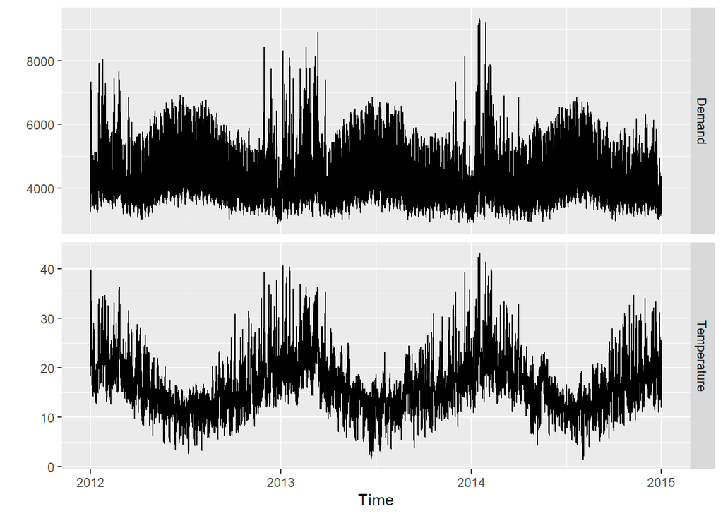

```r
vic_elec |>
  pivot_longer(Demand:Temperature, names_to = "Series") |>
  ggplot(aes(x = Time, y = value)) +
  geom_line() +
  facet_grid(rows = vars(Series), scales = "free_y") +
  labs(y = "")
```

Figure 12.5: Half-hourly electricity demand and corresponding temperatures in 2012–2014, Victoria, Australia.

전력 수요를 온도에 대해 플로팅한 결과(그림 12.6), **온도가 낮거나 높을수록 전력 수요가 증가**하는 **비선형 관계**가 나타난다. 이는 **난방(저온)**과 **냉방(고온)** 수요 때문으로 해석된다.

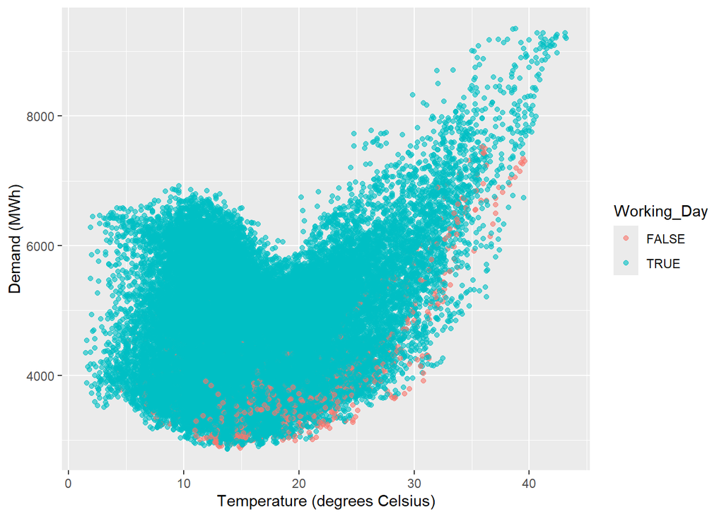

```r
elec <- vic_elec |>
  mutate(
    DOW = wday(Date, label = TRUE),
    Working_Day = !Holiday & !(DOW %in% c("Sat", "Sun")),
    Cooling = pmax(Temperature, 18)
  )
elec |>
  ggplot(aes(x=Temperature, y=Demand, col=Working_Day)) +
  geom_point(alpha = 0.6) +
  labs(x="Temperature (degrees Celsius)", y="Demand (MWh)")
```

Figure 12.6: Half-hourly electricity demand for Victoria, plotted against temperatures for the same times in Melbourne, the largest city in Victoria.

온도에 대해 **절편이 18도인 선형분할 함수(piecewise linear function)**를 포함한 회귀 모형을 적합하며, **일일 계절성**을 반영하기 위해 **고조파 회귀(Fourier 항)**도 함께 사용한다. Fourier 항의 차수는 **주관적으로 설정**하고, **ARIMA 오차 항의 차수는 AICc를 통해 선택**한다.

```r
fit <- elec |>
  model(
    ARIMA(Demand ~ PDQ(0, 0, 0) + pdq(d = 0) +
          Temperature + Cooling + Working_Day +
          fourier(period = "day", K = 10) +
          fourier(period = "week", K = 5) +
          fourier(period = "year", K = 3))
  )
```

이러한 모형으로 예측할 때는 **예측 변수의 미래값이 필요**하기 때문에 어렵다. **Fourier 항은 쉽게 계산 가능**하지만, **미래 온도는 알 수 없으므로 문제가 된다**.

1주일 이내의 예측이라면 **기상청의 온도 예보**를 사용할 수 있고, 그 외에는 **시나리오 기반 예측**(Section 6.5)을 통해 가능한 온도 패턴을 가정하여 수요를 예측할 수 있다.

예시에서는 **최근 이틀간의 온도 데이터를 반복**하여 미래의 전력 수요를 생성하였다.

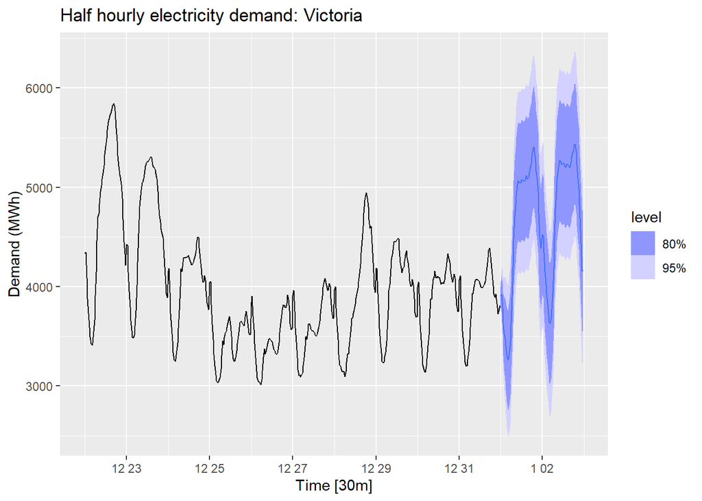

```r
elec_newdata <- new_data(elec, 2*48) |>
  mutate(
    Temperature = tail(elec$Temperature, 2 * 48),
    Date = lubridate::as_date(Time),
    DOW = wday(Date, label = TRUE),
    Working_Day = (Date != "2015-01-01") &
                   !(DOW %in% c("Sat", "Sun")),
    Cooling = pmax(Temperature, 18)
  )
fc <- fit |>
  forecast(new_data = elec_newdata)

fc |>
  autoplot(elec |> tail(10 * 48)) +
  labs(title="Half hourly electricity demand: Victoria",
       y = "Demand (MWh)", x = "Time [30m]")
```

Figure 12.7: Forecasts from a dynamic harmonic regression model applied to half-hourly electricity demand data.

단기 예측은 그럴듯해 보이지만, 이 모형은 복잡한 과정을 단순화한 **조잡한 모형**이다. 그림 12.8에 나타난 **잔차를 보면 상당한 정보가 모형에 반영되지 않았음**을 확인할 수 있다.

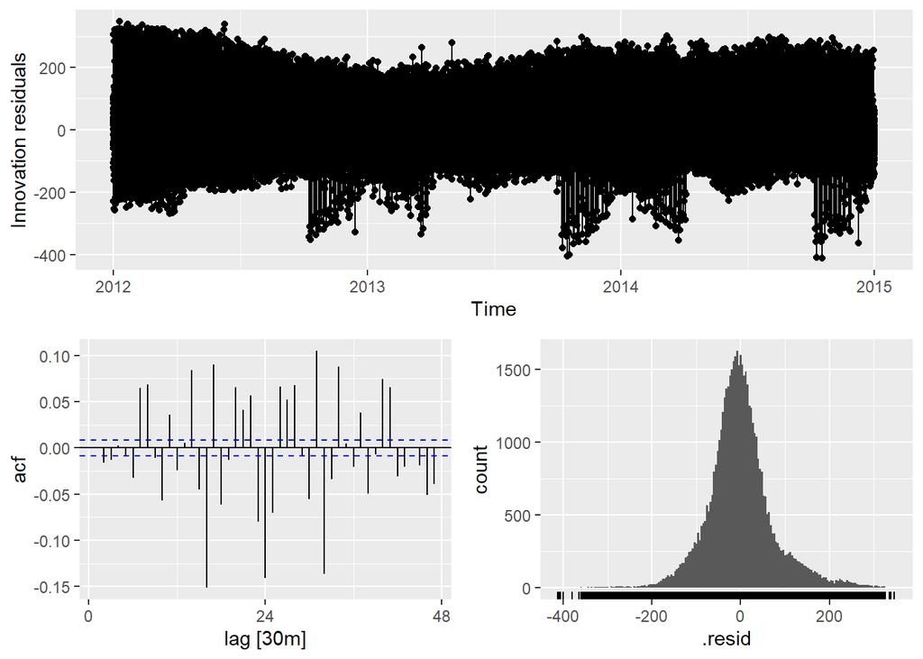

```r
fit |> gg_tsresiduals()
```

Figure 12.8: Residual diagnostics for the dynamic harmonic regression model.